#### `geomsurf` (géométrie surfacique en WKT)

100% manquante dans l’export – aucun polygone de périmètre n’est fourni. Ce champ était prévu pour contenir la géométrie de la friche (polygone). Son absence totale signifie qu’on ne dispose pas des contours des sites, juste des points.  
**Problèmes** : Sans ces polygones, difficile d’évaluer précisément la surface (d’où le champ site_surface mal rempli), d’analyser les recouvrements (avec zones naturelles, etc.) ou d’afficher l’emprise exacte sur une carte.  
**Causes** : Les données sources n’ont pas été livrées avec les géométries, à l’exception de potentiellement quelques observations locales. De plus, inclure des polygones de milliers de sites dans un CSV aurait été lourd – c’est peut-être volontairement exclu de cette exportation (les polygones sont peut-être seulement dans la base SIG du Cerema).  
**Recommandations** : Récupérer et intégrer les polygones lorsque possible. Cela peut se faire via : (a) les parcelles cadastrales si identifiées, en agrégation, (b) les contours fournis par certaines régions ou EPF, (c) du dessin manuel sur orthophoto. C’est un chantier de fond qui dépasse l’urgence, mais c’est crucial pour la suite (notamment mesurer l’avancement du zéro artificialisation nette). À court terme, on pourrait au moins fournir la surface approximative (ce qui avait été tenté via site_surface, mais avec limites vues). Si la décision est de ne pas publier de polygones pour l’instant, il faut clairement le mentionner. Peut-être que dans l’interface Cartofriches, l’emprise est visible mais pas exportée – il faudrait alors expliquer aux utilisateurs de données que seule une localisation ponctuelle est disponible dans le CSV standard.

### 🏙️ Champs Urbanisme

Problèmes de qualité : Cette section présente des valeurs manquantes notables, notamment pour les champs de zonage urbain (par exemple, les zones d’urbanisme peuvent être non renseignées pour de nombreux sites). On observe aussi des formats de données complexes (le champ des distances de desserte compile plusieurs valeurs séparées par des caractères spéciaux, ce qui le rend difficile à exploiter tel quel). De plus, certaines distributions sont très déséquilibrées : une modalité unique domine la plupart des enregistrements (par exemple, un type de document d’urbanisme couvre l’essentiel des sites), réduisant la diversité d’information utile. Interprétation : Ces lacunes et déséquilibres suggèrent que l’intégration des données d’urbanisme n’est pas homogène selon les sites. De nombreux champs non renseignés (ou partiellement formatés) limitent la capacité à analyser l’impact du zonage et de l’accessibilité sur la réutilisation des friches. La dominance d’une valeur unique (par exemple, la majorité des sites sous un même régime d’urbanisme) indique un biais potentiel : l’attribut apporte peu de pouvoir discriminant, ce qui complique l’identification de tendances significatives sur ces critères. Il faudra en tenir compte pour ne pas tirer de conclusions hâtives biaisées par la sur-représentation d’un cas général.

|  | colonne | valeur_manquant_reel | valeur_manquant_effectif | taux_doublons_(%) | Modalite_Dominante | Dominance_(%) | Nb_Valeurs_Uniques | Nb_Lignes_Valides_Selon_Regle | Taux_Validite_Effectif_(%) | Top3_Modalites_Non_Valides |
| --- | --- | --- | --- | --- | --- | --- | --- | --- | --- | --- |
| 0 | urba_zone_type | 3953 | 3953 | 99.96 | U | 66.2 | 10 | 24148 | 99.94 | {'nan': 3953, '99': 13, 'nd': 1} |
| 1 | urba_zone_lib | 3953 | 3953 | 67.78 | ZnC - Secteur non ouvert à la construction, sa... | 2.0 | 9058 | 24162 | 100.00 | {'nan': 3953} |
| 2 | urba_zone_formdomi | 23579 | 23579 | 99.96 | Habitat | 34.1 | 11 | 0 | 0.00 | {'nan': 23579, 'habitat': 1548, 'espace nature... |
| 3 | urba_doc_type | 3851 | 3918 | 99.98 | PLU | 52.5 | 4 | 23061 | 95.31 | {'nan': 3851, 'cc': 1073, 'autre': 67} |
| 4 | desserte_distance | 28115 | 28115 | 100.00 | None | NaN | 0 | 0 | 0.00 | {'nan': 28115} |
| 5 | desserte_commentaire | 28115 | 28115 | 100.00 | None | NaN | 0 | 0 | 0.00 | {'nan': 28115} |
| 6 | TOTAL DOMAINE | 91566 | 91633 | 94.61 | N/A | N/A | N/A | 71371 | 92.62 | N/A |

urba_doc_type À surveiller

#### `urba_doc_type`

urba_zone_type À surveiller

#### `urba_zone_type` (type de zone de planification)

urba_zone_lib À surveiller

#### `urba_zone_lib` (libellé de la zone d’urbanisme)

urba_zone_formdomi Inexploitable

#### `urba_zone_formdomi` (forme dominante de la zone)

```
urba_zone_formdomi
Habitat                                               1548
Espace naturel                                         862
Activité économique                                    702
Activité agricole                                      682
Mixte habitat/activité                                 390
Autres                                                 137
Equipements public                                      94
Sans objet ou non encore définie dans le règlement      42
Loisirs et tourisme                                     38
Espace remarquable                                      25
Secteur de carrière                                     16
Name: count, dtype: int64
```

deserte_distance Inexploitable mais critique

#### deserte_distance, deserte_commentaire

ces champs on été laissé complètement vide, cela peut être du a l'accessibilité de croissement de données, pourtant ce champs est utilisé dans les indices de mutabilité **Recommendation** encore une fois, il serait intéressant d'utiliser différentes sources de bases de données pour compléter ces champs, c'est un travail exhaustif qui necessiterai à terme une reconnaissance automatisé puis un avis expert ou une visite terrain pour la confirmation des features.

### ☣️ Pollution

Les informations relatives à la pollution des sites (présence de contaminants, types de pollution) sont cruciales mais présentent des problèmes de complétude et de cohérence : Informations manquantes sur la pollution : La majorité des sites ne comportent pas de détails sur une éventuelle pollution. Souvent, le statut "pollué ou non" n’est pas renseigné et aucun liste de polluants n’est fournie, reflétant un manque de données dans ce domaine. Faible proportion de sites déclarés pollués : Parmi les sites qui ont une information, relativement peu sont explicitement marqués comme pollués. Cela peut signifier soit que peu de friches ont été évaluées et confirmées polluées, soit que la donnée est incomplète (de nombreux sites potentiellement pollués restent non confirmés). Types de polluants dominants : Dans les cas où des types de pollution sont indiqués, on observe que quelques catégories reviennent fréquemment (par ex. métaux lourds, hydrocarbures) tandis que d’autres contaminants sont rares. Cette concentration peut indiquer des industries prédominantes dans la région ou une focalisation sur certains polluants lors des diagnostics. Incohérences éventuelles : Il existe des situations où les données de pollution sont contradictoires, par exemple un site marqué "non pollué" alors qu’un type de polluant est listé ailleurs, ou des valeurs de concentration de polluants sans indication claire d’unité ou de seuil de danger.

|  | colonne | valeur_manquant_reel | valeur_manquant_effectif | taux_doublons_(%) | Modalite_Dominante | Dominance_(%) | Nb_Valeurs_Uniques | Nb_Lignes_Valides_Selon_Regle | Taux_Validite_Effectif_(%) | Top3_Modalites_Non_Valides |
| --- | --- | --- | --- | --- | --- | --- | --- | --- | --- | --- |
| 0 | sol_pollution_annee | 28115 | 28115 | 100.00 | None | NaN | 0 | 0 | 0.00 | {'nan': 28115} |
| 1 | sol_pollution_existe | 0 | 24816 | 99.98 | pollution supposée | 46.2 | 6 | 0 | 0.00 | {'inconnu': 24816, 'pollution supposée': 1523,... |
| 2 | sol_pollution_origine | 0 | 28085 | 99.99 | pollution due au fonctionnement de l'installation | 56.7 | 3 | 0 | 0.00 | {'inconnu': 28085, 'pollution due au fonctionn... |
| 3 | sol_pollution_commentaire | 28115 | 28115 | 100.00 | None | NaN | 0 | 0 | 0.00 | {'nan': 28115} |
| 4 | sol_depollution_fiche | 28112 | 28112 | 99.99 | https://fiches-risques.brgm.fr/georisques/info... | 33.3 | 3 | 3 | 100.00 | {'nan': 28112} |
| 5 | site_securite | 5822 | 25954 | 99.98 | évacuation des produits dangereux et déchets p... | 99.2 | 4 | 0 | 0.00 | {'inconnu': 20132, 'nan': 5822, 'évacuation de... |
| 6 | bati_pollution | 0 | 26883 | 99.99 | amiante | 98.2 | 2 | 0 | 0.00 | {'inconnu': 26753, 'amiante': 1210, 'autre': 130} |
| 7 | TOTAL DOMAINE | 90164 | 190080 | 99.99 | N/A | N/A | N/A | 3 | 0.04 | N/A |

Interprétation et recommandations : La forte proportion de données manquantes sur la pollution signifie qu’on ne peut pas conclure qu’un site sans information est sain – simplement qu’il n’a pas été évalué ou documenté. Pour une analyse environnementale fiable, il faudrait compléter ces informations en menant des études de terrain ou en croisant avec des bases spécialisées (telles que BASOL, qui recense les sites pollués avérés). Le faible nombre de sites déclarés pollués dans la base actuelle peut minimiser le problème aux yeux des décideurs ; il est donc conseillé de souligner que l’absence de preuve de pollution ne prouve pas l’absence de pollution. La prédominance de certains polluants (ex. métaux lourds) suggère de cibler ces contaminants dans les plans de réhabilitation, mais aussi de vérifier si d’autres polluants n’ont pas été sous-déclarés faute d’analyses approfondies. Enfin, les incohérences doivent être résolues en nettoyant la base : par exemple, uniformiser le statut pollué en fonction de la présence effective de polluants, et clarifier les unités ou seuils utilisés pour les concentrations afin d’éviter toute mauvaise interprétation.

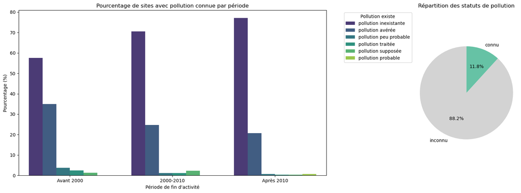

sol_pollution_annee Inexploitable